# CIV1498 - Introduction to Data Science

## Project - Bike Share Toronto

## Part 3 - Modelling

The following topics will be investigated in the third part of the project:

- Potential features for modelling
- The performances of different models
- The final model

## Setup Notebook

```python
# Import 3rd party libraries
import os
import numpy as np
import pandas as pd
import seaborn as sns
import matplotlib.pyplot as plt

# Configure Notebook
%matplotlib inline
plt.style.use('fivethirtyeight')
sns.set_context("notebook")
import warnings
warnings.filterwarnings('ignore')
```

## Load data

```python
# Mount Google Drive
from google.colab import drive
drive.mount("/content/drive")
```

```python
# Load merged data
data_merged = pd.read_csv('/content/drive/My Drive/CIV1498 Project 2021/data_merged.csv', index_col = 0)
data_merged.head()
```

|  | Trip Id | Trip Duration | Start Station Id | Start Time | Start Station Name | End Station Id | End Time | End Station Name | User Type | Start_lat | Start_lon | Start_capacity | End_lat | End_lon | End_capacity | Temp (°C) | Dew Point Temp (°C) | Rel Hum (%) | Wind Dir (10s deg) | Wind Spd (km/h) | Visibility (km) | Hmdx | Wind Chill | Weather |
| --- | --- | --- | --- | --- | --- | --- | --- | --- | --- | --- | --- | --- | --- | --- | --- | --- | --- | --- | --- | --- | --- | --- | --- | --- |
| 0 | 712441 | 274 | 7006.0 | 2017-01-01 00:00:00-05:00 | Bay St / College St (East Side) | 7021.0 | 2017-01-01 00:08:00-05:00 | Bay St / Albert St | Member | 43.660439 | -79.385525 | 11 | 43.653264 | -79.382458 | 35 | 1.5 | -3.6 | 69.0 | 26.0 | 39.0 | 16.1 | NaN | NaN | Clear |
| 90955 | 712439 | 453 | 7026.0 | 2017-01-01 00:00:00-05:00 | Bay St / St. Joseph St | 7027.0 | 2016-12-31 23:58:00-05:00 | Beverley St / Dundas St W | Member | 43.665527 | -79.387499 | 15 | 43.652823 | -79.393388 | 31 | 1.5 | -3.6 | 69.0 | 26.0 | 39.0 | 16.1 | NaN | NaN | Clear |
| 969587 | 712445 | 645 | 7076.0 | 2017-01-01 00:00:00-05:00 | York St / Queens Quay W | 7010.0 | 2017-01-01 00:25:00-05:00 | King St W / Spadina Ave | Member | 43.640132 | -79.380464 | 27 | 43.645323 | -79.395003 | 19 | 1.5 | -3.6 | 69.0 | 26.0 | 39.0 | 16.1 | NaN | NaN | Clear |
| 1453301 | 712431 | 494 | 7163.0 | 2017-01-01 00:00:00-05:00 | Yonge St / Wood St | 7634.0 | 2016-12-31 23:51:00-05:00 | University Ave / Gerrard St W (West Side) | Member | 43.662222 | -79.382500 | 15 | 43.657845 | -79.389927 | 18 | 1.5 | -3.6 | 69.0 | 26.0 | 39.0 | 16.1 | NaN | NaN | Clear |
| 1453302 | 712432 | 425 | 7163.0 | 2017-01-01 00:00:00-05:00 | Yonge St / Wood St | 7634.0 | 2016-12-31 23:50:00-05:00 | University Ave / Gerrard St W (West Side) | Member | 43.662222 | -79.382500 | 15 | 43.657845 | -79.389927 | 18 | 1.5 | -3.6 | 69.0 | 26.0 | 39.0 | 16.1 | NaN | NaN | Clear |

```python
# Set trip start datetime as index
data_merged2 = data_merged.copy()
data_merged2.index = pd.to_datetime(data_merged2['Start Time'])
data_merged2.head()
```

| Start Time | Trip Id | Trip Duration | Start Station Id | Start Time | Start Station Name | End Station Id | End Time | End Station Name | User Type | Start_lat | Start_lon | Start_capacity | End_lat | End_lon | End_capacity | Temp (°C) | Dew Point Temp (°C) | Rel Hum (%) | Wind Dir (10s deg) | Wind Spd (km/h) | Visibility (km) | Hmdx | Wind Chill | Weather |
| --- | --- | --- | --- | --- | --- | --- | --- | --- | --- | --- | --- | --- | --- | --- | --- | --- | --- | --- | --- | --- | --- | --- | --- | --- |
| 2017-01-01 00:00:00-05:00 | 712441 | 274 | 7006.0 | 2017-01-01 00:00:00-05:00 | Bay St / College St (East Side) | 7021.0 | 2017-01-01 00:08:00-05:00 | Bay St / Albert St | Member | 43.660439 | -79.385525 | 11 | 43.653264 | -79.382458 | 35 | 1.5 | -3.6 | 69.0 | 26.0 | 39.0 | 16.1 | NaN | NaN | Clear |
| 2017-01-01 00:00:00-05:00 | 712439 | 453 | 7026.0 | 2017-01-01 00:00:00-05:00 | Bay St / St. Joseph St | 7027.0 | 2016-12-31 23:58:00-05:00 | Beverley St / Dundas St W | Member | 43.665527 | -79.387499 | 15 | 43.652823 | -79.393388 | 31 | 1.5 | -3.6 | 69.0 | 26.0 | 39.0 | 16.1 | NaN | NaN | Clear |
| 2017-01-01 00:00:00-05:00 | 712445 | 645 | 7076.0 | 2017-01-01 00:00:00-05:00 | York St / Queens Quay W | 7010.0 | 2017-01-01 00:25:00-05:00 | King St W / Spadina Ave | Member | 43.640132 | -79.380464 | 27 | 43.645323 | -79.395003 | 19 | 1.5 | -3.6 | 69.0 | 26.0 | 39.0 | 16.1 | NaN | NaN | Clear |
| 2017-01-01 00:00:00-05:00 | 712431 | 494 | 7163.0 | 2017-01-01 00:00:00-05:00 | Yonge St / Wood St | 7634.0 | 2016-12-31 23:51:00-05:00 | University Ave / Gerrard St W (West Side) | Member | 43.662222 | -79.382500 | 15 | 43.657845 | -79.389927 | 18 | 1.5 | -3.6 | 69.0 | 26.0 | 39.0 | 16.1 | NaN | NaN | Clear |
| 2017-01-01 00:00:00-05:00 | 712432 | 425 | 7163.0 | 2017-01-01 00:00:00-05:00 | Yonge St / Wood St | 7634.0 | 2016-12-31 23:50:00-05:00 | University Ave / Gerrard St W (West Side) | Member | 43.662222 | -79.382500 | 15 | 43.657845 | -79.389927 | 18 | 1.5 | -3.6 | 69.0 | 26.0 | 39.0 | 16.1 | NaN | NaN | Clear |

```python
# Define statutory holidays
statutory_holidays = ['2017-01-02', '2017-02-20', '2017-04-14', '2017-05-22', '2017-07-03', '2017-08-07', '2017-09-04', '2017-10-09', '2017-12-25', '2017-12-26',
                      '2018-01-01', '2018-02-19', '2018-03-30', '2018-05-21', '2018-07-02', '2018-08-06', '2018-09-03', '2018-10-08', '2018-12-25', '2018-12-26',
                      '2019-01-01', '2019-02-18', '2019-04-19', '2019-05-20', '2019-07-01', '2019-08-05', '2019-09-02', '2019-10-14', '2019-12-25', '2019-12-26',
                      '2020-01-01', '2020-02-17', '2020-04-10', '2020-05-18', '2020-07-01', '2020-08-03', '2020-09-07', '2020-10-12', '2020-12-25', '2020-12-28']
```

# 1 Feature engineering

## 1.1 Generate hourly rides with potential features

```python
# Generate hourly number of rides, average hourly trip duration, and hourly weather data
hourly_data = data_merged2.groupby(data_merged2.index.floor('H')).agg(rides = ('Trip Id', 'count'),
                                                    year = ('Start Time', lambda x: pd.to_datetime(x[0]).year),
                                                    month = ('Start Time', lambda x: pd.to_datetime(x[0]).month),
                                                    day = ('Start Time', lambda x: pd.to_datetime(x[0]).weekday()),
                                                    hour = ('Start Time', lambda x: pd.to_datetime(x[0]).hour),
                                                    temp = ('Temp (°C)', 'mean'),
                                                    dew_temp = ('Dew Point Temp (°C)', 'mean'),
                                                    rel_hum = ('Rel Hum (%)', 'mean'),
                                                    wind_speed = ('Wind Spd (km/h)', 'mean'),
                                                    visibility = ('Visibility (km)', 'mean'),
                                                    humidex = ('Hmdx', 'mean'),
                                                    wind_chill = ('Wind Chill', 'mean'),
                                                    precipitation = ('Weather', lambda p: bool(sum(p.str.contains('rain|snow', case = False)))),
                                                    Weather = ('Weather', lambda w: w.iloc[0]),
                                                    )

# Create a new column based on the 'Weather' column stating if the weather is clear or not
weather_cond = data_merged2['Weather'].unique()
hourly_data['Weather_simple'] = hourly_data['Weather'].replace(np.delete(weather_cond, np.where(weather_cond == 'Clear')).tolist(), value = 'Non-clear')

# Creat a new column for statutory holiday
hourly_data['holiday'] = hourly_data.apply(lambda x: x.name.strftime("%Y-%m-%d") in statutory_holidays, axis=1)

# Creat a new column for weekends
hourly_data['weekend'] = hourly_data.apply(lambda x: x['day'] > 4, axis=1)

# Creat a new column for period of the day, 1 for early morning (12 am - 6 am), 2 for daytime (6 am - 6 pm), and 3 for night (6 pm - 12 am)
hourly_data['period'] = hourly_data.apply(lambda x: 1 if (x['hour'] < 6) else (2 if (x['hour'] < 18) else 3), axis=1)

# Reset index
hourly_data = hourly_data.reset_index().drop(['Start Time'], axis=1)

hourly_data.head()
```

|  | rides | year | month | day | hour | temp | dew_temp | rel_hum | wind_speed | visibility | humidex | wind_chill | precipitation | Weather | Weather_simple | holiday | weekend | period |
| --- | --- | --- | --- | --- | --- | --- | --- | --- | --- | --- | --- | --- | --- | --- | --- | --- | --- | --- |
| 0 | 20 | 2017 | 1 | 6 | 0 | 1.5 | -3.6 | 69.0 | 39.0 | 16.1 | NaN | NaN | False | Clear | Clear | False | True | 1 |
| 1 | 15 | 2017 | 1 | 6 | 1 | 1.5 | -3.9 | 67.0 | 35.0 | 16.1 | NaN | NaN | False | Clear | Clear | False | True | 1 |
| 2 | 15 | 2017 | 1 | 6 | 2 | 1.0 | -4.3 | 68.0 | 32.0 | 16.1 | NaN | NaN | False | Clear | Clear | False | True | 1 |
| 3 | 11 | 2017 | 1 | 6 | 3 | 1.2 | -4.3 | 67.0 | 37.0 | 16.1 | NaN | NaN | False | Clear | Clear | False | True | 1 |
| 4 | 7 | 2017 | 1 | 6 | 4 | 1.3 | -4.4 | 66.0 | 28.0 | 16.1 | NaN | NaN | False | Clear | Clear | False | True | 1 |

```python
# Split data into training and testing set
from sklearn.model_selection import train_test_split

train, test = train_test_split(hourly_data, test_size=0.30, random_state=0)

# Print results
print('Train {}%'.format(round(train.shape[0] / hourly_data.shape[0] * 100, 2)))
print('Test {}%'.format(round(test.shape[0] / hourly_data.shape[0] * 100, 2)))
```

```
Train 70.0%
Test 30.0%
```

## 1.2 Consideration of hours with low demand

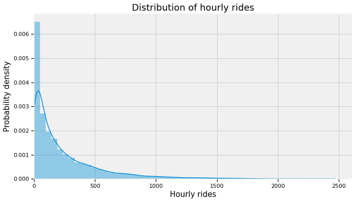

```python
# Distribution of hourly rides
plt.figure(figsize=(10, 6))
plt.title('Distribution of hourly rides', fontsize=18)
sns.distplot(train['rides'])
plt.xlabel('Hourly rides', fontsize=15)
plt.ylabel('Probability density', fontsize=15)
plt.xlim(left = 0);
```

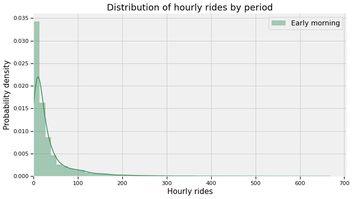

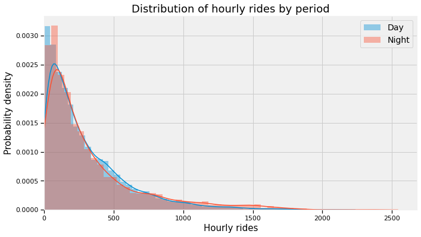

```python
# Distribution of hourly rides for each period
plt.figure(figsize=(10, 6))
plt.title('Distribution of hourly rides by period', fontsize=18)
sns.distplot(train[train['period'] == 1]['rides'], label = 'Early morning', color='seagreen')
plt.xlabel('Hourly rides', fontsize=15)
plt.ylabel('Probability density', fontsize=15)
plt.xlim(left = 0)
plt.legend(fontsize = 14);

plt.figure(figsize=(10, 6))
plt.title('Distribution of hourly rides by period', fontsize=18)
sns.distplot(train[train['period'] == 2]['rides'], label = 'Day')
sns.distplot(train[train['period'] == 3]['rides'], label = 'Night')
plt.xlabel('Hourly rides', fontsize=15)
plt.ylabel('Probability density', fontsize=15)
plt.xlim(left = 0)
plt.legend(fontsize = 14);
```

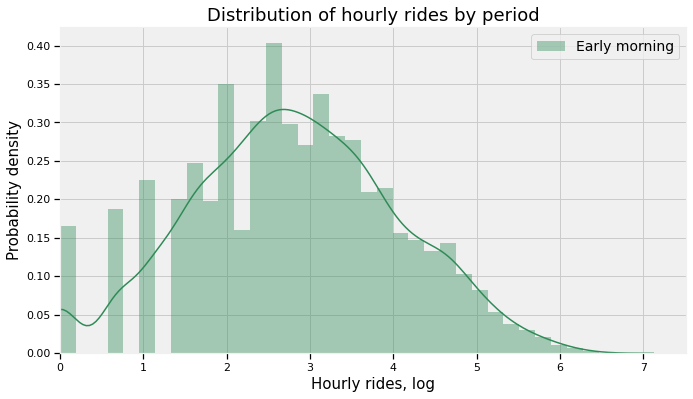

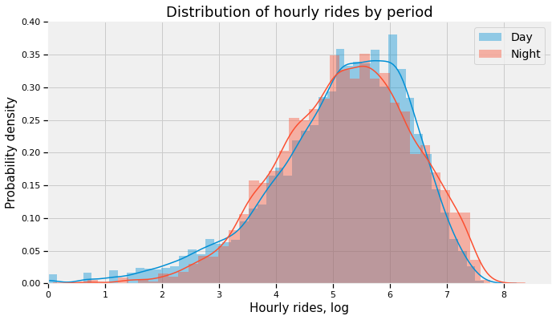

```python
# Distribution of hourly rides (log transformed) for each period
plt.figure(figsize=(10, 6))
plt.title('Distribution of hourly rides by period', fontsize=18)
sns.distplot(np.log(train[train['period'] == 1]['rides']), label = 'Early morning', color='seagreen')
plt.xlabel('Hourly rides, log', fontsize=15)
plt.ylabel('Probability density', fontsize=15)
plt.xlim(left = 0)
plt.legend(fontsize = 14);

plt.figure(figsize=(10, 6))
plt.title('Distribution of hourly rides by period', fontsize=18)
sns.distplot(np.log(train[train['period'] == 2]['rides']), label = 'Day')
sns.distplot(np.log(train[train['period'] == 3]['rides']), label = 'Night')
plt.xlabel('Hourly rides, log', fontsize=15)
plt.ylabel('Probability density', fontsize=15)
plt.xlim(left = 0)
plt.legend(fontsize = 14);
```

It can be seen that there are very few demands during early morning (0-6AM). Thus our focus of this part is to estimate the hourly demand during daytime and night. So the data of early morning will be filtered out, and the filtered data is splitted as follows.

```python
hourly_data_filter = hourly_data[hourly_data['period'] != 1]

# Split data into training and testing set
train, test = train_test_split(hourly_data_filter, test_size=0.30, random_state=0)

# Print results
print('Train {}%'.format(round(train.shape[0] / hourly_data_filter.shape[0] * 100, 2)))
print('Test {}%'.format(round(test.shape[0] / hourly_data_filter.shape[0] * 100, 2)))
```

```
Train 70.0%
Test 30.0%
```

## 1.3 Rides for different months and days

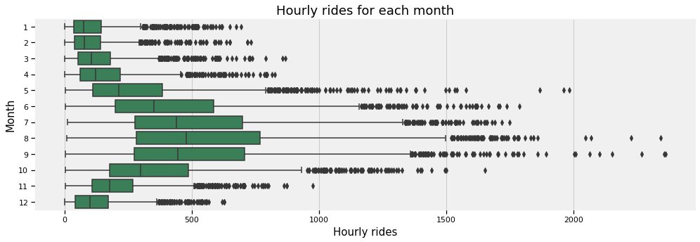

```python
# Boxplot of hourly rides for each month
plt.figure(figsize=(15, 5))
plt.title('Hourly rides for each month', fontsize=18)
sns.boxplot(y='month', x='rides', data=train, color="seagreen", orient = 'horizontal')
plt.ylabel('Month', fontsize=15)
plt.xlabel('Hourly rides', fontsize=15);
```

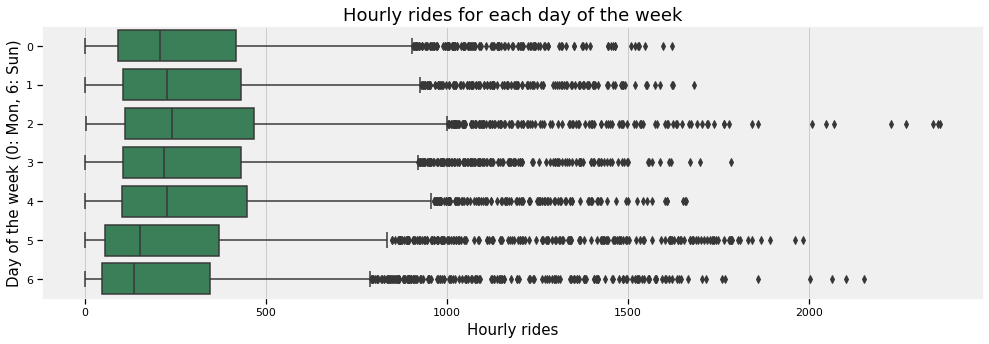

```python
# Boxplot of hourly rides for each day of the week
plt.figure(figsize=(15, 5))
plt.title('Hourly rides for each day of the week', fontsize=18)
sns.boxplot(y='day', x='rides', data=train, color="seagreen", orient = 'horizontal')
plt.ylabel('Day of the week (0: Mon, 6: Sun)', fontsize=15)
plt.xlabel('Hourly rides', fontsize=15);
```

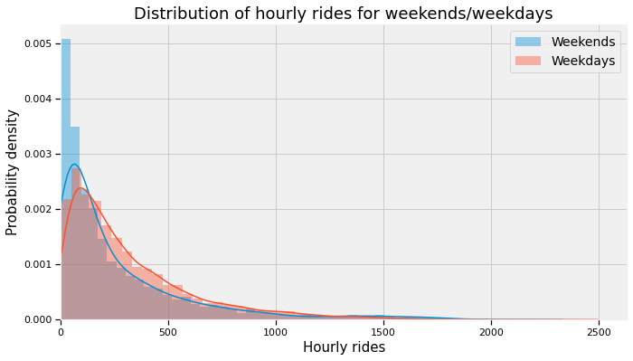

```python
# Distribution of hourly rides for weekends/weekdays
plt.figure(figsize=(10, 6))
plt.title('Distribution of hourly rides for weekends/weekdays', fontsize=18)
sns.distplot(train[train['weekend'] == True]['rides'], label = 'Weekends')
sns.distplot(train[train['weekend'] == False]['rides'], label = 'Weekdays')
plt.xlabel('Hourly rides', fontsize=15)
plt.ylabel('Probability density', fontsize=15)
plt.xlim(left = 0)
plt.legend(fontsize = 14);
```

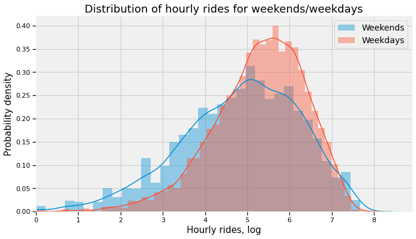

```python
# Distribution of hourly rides (log transformed) for weekends/weekdays
plt.figure(figsize=(10, 6))
plt.title('Distribution of hourly rides for weekends/weekdays', fontsize=18)
sns.distplot(np.log(train[train['weekend'] == True]['rides']), label = 'Weekends')
sns.distplot(np.log(train[train['weekend'] == False]['rides']), label = 'Weekdays')
plt.xlabel('Hourly rides, log', fontsize=15)
plt.ylabel('Probability density', fontsize=15)
plt.xlim(left = 0)
plt.legend(fontsize = 14);
```

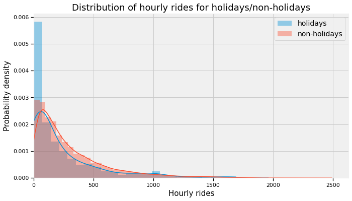

```python
# Distribution of hourly rides for holidays/non-holidays
plt.figure(figsize=(10, 6))
plt.title('Distribution of hourly rides for holidays/non-holidays', fontsize=18)
sns.distplot(train[train['holiday'] == True]['rides'], label = 'holidays')
sns.distplot(train[train['holiday'] == False]['rides'], label = 'non-holidays')
plt.xlabel('Hourly rides', fontsize=15)
plt.ylabel('Probability density', fontsize=15)
plt.xlim(left = 0)
plt.legend(fontsize = 14);
```

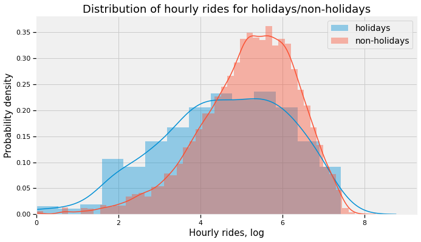

```python
# Distribution of hourly rides (log transformed) for holidays/non-holidays
plt.figure(figsize=(10, 6))
plt.title('Distribution of hourly rides for holidays/non-holidays', fontsize=18)
sns.distplot(np.log(train[train['holiday'] == True]['rides']), label = 'holidays')
sns.distplot(np.log(train[train['holiday'] == False]['rides']), label = 'non-holidays')
plt.xlabel('Hourly rides, log', fontsize=15)
plt.ylabel('Probability density', fontsize=15)
plt.xlim(left = 0)
plt.legend(fontsize = 14);
```

Overall, different months, days of the week, special days (i.e. weekends and holidays) influence ridership. Since weekend correlates with days of the week, it will be omitted during modelling.

## 1.4 Rides for different weathers

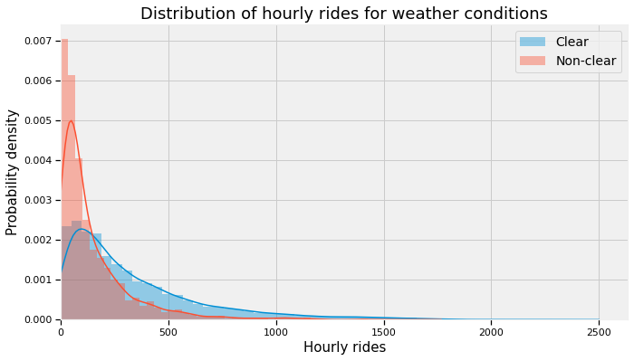

```python
# Distribution of hourly rides for weather conditions
plt.figure(figsize=(10, 6))
plt.title('Distribution of hourly rides for weather conditions', fontsize=18)
sns.distplot(train[train['Weather_simple'] == 'Clear']['rides'], label = 'Clear')
sns.distplot(train[train['Weather_simple'] == 'Non-clear']['rides'], label = 'Non-clear')
plt.xlabel('Hourly rides', fontsize=15)
plt.ylabel('Probability density', fontsize=15)
plt.xlim(left = 0)
plt.legend(fontsize = 14);
```

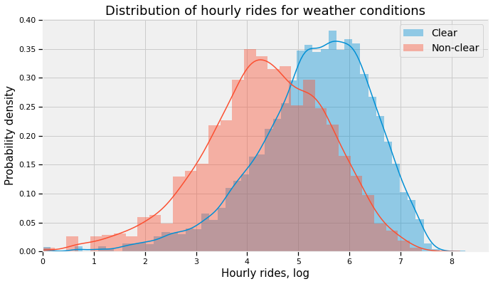

```python
# Distribution of hourly rides (log transformed) for weather conditions
plt.figure(figsize=(10, 6))
plt.title('Distribution of hourly rides for weather conditions', fontsize=18)
sns.distplot(np.log(train[train['Weather_simple'] == 'Clear']['rides']), label = 'Clear')
sns.distplot(np.log(train[train['Weather_simple'] == 'Non-clear']['rides']), label = 'Non-clear')
plt.xlabel('Hourly rides, log', fontsize=15)
plt.ylabel('Probability density', fontsize=15)
plt.xlim(left = 0)
plt.legend(fontsize = 14);
```

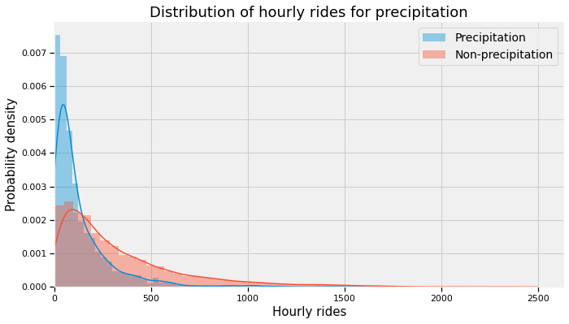

```python
# Distribution of hourly rides for weather conditions
plt.figure(figsize=(10, 6))
plt.title('Distribution of hourly rides for precipitation', fontsize=18)
sns.distplot(train[train['precipitation'] == True]['rides'], label = 'Precipitation')
sns.distplot(train[train['precipitation'] == False]['rides'], label = 'Non-precipitation')
plt.xlabel('Hourly rides', fontsize=15)
plt.ylabel('Probability density', fontsize=15)
plt.xlim(left = 0)
plt.legend(fontsize = 14);
```

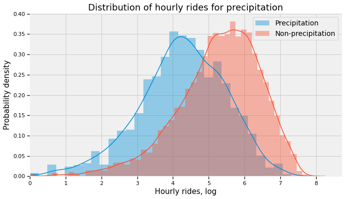

```python
# Distribution of hourly rides (log transformed) for weather conditions
plt.figure(figsize=(10, 6))
plt.title('Distribution of hourly rides for precipitation', fontsize=18)
sns.distplot(np.log(train[train['precipitation'] == True]['rides']), label = 'Precipitation')
sns.distplot(np.log(train[train['precipitation'] == False]['rides']), label = 'Non-precipitation')
plt.xlabel('Hourly rides, log', fontsize=15)
plt.ylabel('Probability density', fontsize=15)
plt.xlim(left = 0)
plt.legend(fontsize = 14);
```

In addition to the observations during exploratory data analysis, temperature, weather condition, and wind speed were identified as the most impacting weather features; therefore, they will be used in the model. Although relative humidity did not appear to have any effect, it is added as it is an independent weather variable.

# 2 Model evaluation and selection

The architecture that will be used is the linear regression model. Ideally, other model architectures such as polynomial regression, random forest, and neural networks should be tested, but linear regression is sufficient for a simple preliminary model.

Cross-Validation (CV) is important for developing machine learning models, so it will be used to compare and evaluate the different models. In this case, the k-fold CV will be used with k = 5. This is a common method of conducting the CV step.

The evaluation metric for the models will be the root mean squared error as it is very commonly used.

```python
# Import scikit-learn libraries for modelling
from sklearn.linear_model import LinearRegression
from sklearn.model_selection import KFold
from sklearn.base import clone
from sklearn.preprocessing import StandardScaler
```

```python
# Create the root-mean-squared error function
def rmse(actual, predicted):
    """
    Calculates RMSE from actual and predicted values
    Input:
      actual (1D array): vector of actual values
      predicted (1D array): vector of predicted/fitted values
    Output:
      a float, the root-mean square error
    """

    # Write your code here.
    return np.sqrt(((actual-predicted)**2).mean())
```

## 2.1 Model 0 (Naive)

It is useful to have a baseline model for comparison when investigating different models. In this case, the naive model is simply the mean of the training set.

```python
# Create training and validation set for this model only
train_naive, val_naive = train_test_split(train, test_size=0.15, random_state=0)

# RMSE of the naive model
val_error_0 = rmse(val_naive['rides'], train_naive['rides'].mean())
print('Naive RMSE: {} rides'.format(round(val_error_0,2)))
```

```
Naive RMSE: 312.1 rides
```

## 2.2 Model 1

The first model will use "time type" variables, which are the following features:

- month of the year
- day of the week
- hour of the day
- holiday or not

```python
# K-Fold Cross-Validation function
def cross_validate_rmse_kfold(model, X, y):
    # Setup
    model = clone(model)
    five_fold = KFold(n_splits=5, shuffle = False)
    rmse_values = []

    # Iterature thought cv-folds
    for train_index, val_index in five_fold.split(X):

        # Splitting dataset into training and validation
        X_train = X.iloc[train_index, :]
        X_val = X.iloc[val_index, :]
        y_train = y.iloc[train_index]
        y_val = y.iloc[val_index]

        # Fit model
        model.fit(X_train, y_train)

        # Append RMSE scores
        rmse_values.append(rmse(y_val, model.predict(X_val)))

    return rmse_values, model
```

```python
# Creating pipeline

def process_data(df, num_features, cat_features):
    """Process the data for hourly rides with the features to be used."""

    if num_features is not None:

      # Fit scaler (basically get the mean and stdev) for the training data
      scaler = StandardScaler()
      scaler.fit(df[num_features])
      scaled = df[num_features].copy()

      # Convert numeric features to standard units
      scaled.iloc[:, :] = scaler.transform(scaled)

    else:

      # If there are no numerical features, create a filler dataframe of zeros with the same index
      scaled = pd.DataFrame(np.zeros((df.shape[0], 1)), columns = ['fill'], index = df.index)

    if cat_features is not None:

      # Convert categorical features using dummy encoding
      categoricals = [pd.get_dummies(df[s], prefix=s, drop_first=True) for s in cat_features]

    else:

      # If there are no categorical features, create a filler dataframe of zeros with the same index
      categoricals = [pd.DataFrame(np.zeros((df.shape[0], 1)), columns = ['fill'], index = df.index)]

    # Return predictors and response variables separately
    X = pd.concat([scaled] + categoricals, axis=1)
    y = df.loc[:, 'rides']

    # Remove the filler column
    if 'fill' in X.columns:
      X.drop(columns = 'fill', inplace = True)

    return X, y

# Test the pipeline
num_features = ['temp']
cat_features = ['month', 'day', 'hour', 'holiday']
X,y = process_data(train, num_features, cat_features)
X.head()
```

|  | temp | month_2 | month_3 | month_4 | month_5 | month_6 | month_7 | month_8 | month_9 | month_10 | month_11 | month_12 | day_1 | day_2 | day_3 | day_4 | day_5 | day_6 | hour_7 | hour_8 | hour_9 | hour_10 | hour_11 | hour_12 | hour_13 | hour_14 | hour_15 | hour_16 | hour_17 | … |
| --- | --- | --- | --- | --- | --- | --- | --- | --- | --- | --- | --- | --- | --- | --- | --- | --- | --- | --- | --- | --- | --- | --- | --- | --- | --- | --- | --- | --- | --- | --- |
| 12148 | 0.968904 | 0 | 0 | 0 | 1 | 0 | 0 | 0 | 0 | 0 | 0 | 0 | 0 | 0 | 0 | 0 | 1 | 0 | 0 | 0 | 0 | 0 | 0 | 1 | 0 | 0 | 0 | 0 | 0 | … |
| 30304 | 1.237329 | 0 | 0 | 0 | 0 | 1 | 0 | 0 | 0 | 0 | 0 | 0 | 1 | 0 | 0 | 0 | 0 | 0 | 0 | 0 | 0 | 0 | 0 | 1 | 0 | 0 | 0 | 0 | 0 | … |
| 23777 | 1.028554 | 0 | 0 | 0 | 0 | 0 | 0 | 0 | 1 | 0 | 0 | 0 | 1 | 0 | 0 | 0 | 0 | 0 | 0 | 0 | 0 | 0 | 0 | 0 | 0 | 0 | 0 | 0 | 0 | … |
| 3464 | 0.620945 | 0 | 0 | 0 | 1 | 0 | 0 | 0 | 0 | 0 | 0 | 0 | 0 | 0 | 0 | 0 | 1 | 0 | 0 | 0 | 1 | 0 | 0 | 0 | 0 | 0 | 0 | 0 | 0 | … |
| 4542 | 1.048437 | 0 | 0 | 0 | 0 | 0 | 1 | 0 | 0 | 0 | 0 | 0 | 1 | 0 | 0 | 0 | 0 | 0 | 0 | 0 | 0 | 0 | 1 | 0 | 0 | 0 | 0 | 0 | 0 | … |

```python
# Define numerical features to use
num_features = None

# Define categorical features to use
cat_features = ['month', 'day', 'hour', 'holiday']

# Model and output error
X_train, y_train = process_data(train, num_features, cat_features)
val_errors_1, model_1 = cross_validate_rmse_kfold(model = LinearRegression(fit_intercept = True), X = X_train, y = y_train)

# Calculate the average validation error
val_error_1 = np.mean(val_errors_1)

# Print cv scores
print('Cross-validation k-fold RMSE scores: {} rides'.format(val_errors_1))
print('Cross-validation k-fold RMSE scores mean: {} rides'.format(round(val_error_1, 2)))
print('Cross-validation k-fold RMSE scores std: {} rides'.format(round(np.std(val_errors_1), 2)))
```

```
Cross-validation k-fold RMSE scores: [219.62992890864453, 219.91492607361104, 217.95842653495671, 212.8671576448165, 216.36268431982162] rides
Cross-validation k-fold RMSE scores mean: 217.35 rides
Cross-validation k-fold RMSE scores std: 2.58 rides
```

## 2.3 Model 2

The second model will use the "time" and "weather" type variables, which are the following features:

- temperature
- relative humidity
- wind speed
- month of the year
- day of the week
- hour of the day
- holiday or not
- clear weather or not

```python
# K-Fold Cross-Validation function
def cross_validate_rmse_kfold(model, X, y):

    # Setup
    model = clone(model)
    five_fold = KFold(n_splits=5, shuffle = False)
    rmse_values = []

    # Iterature thought cv-folds
    for train_index, val_index in five_fold.split(X):

        # Splitting dataset into training and validation
        X_train = X.iloc[train_index, :]
        X_val = X.iloc[val_index, :]
        y_train = y.iloc[train_index]
        y_val = y.iloc[val_index]

        # Fit model
        model.fit(X_train, y_train)

        # Append RMSE scores
        rmse_values.append(rmse(y_val, model.predict(X_val)))

    return rmse_values, model
```

```python
# Creating pipeline

def process_data(df, num_features, cat_features):
    """Process the data for hourly rides with the features to be used."""

    if num_features is not None:

      # Fit scaler (basically get the mean and stdev) for the training data
      scaler = StandardScaler()
      scaler.fit(df[num_features])
      scaled = df[num_features].copy()

      # Convert numeric features to standard units
      scaled.iloc[:, :] = scaler.transform(scaled)

    else:

      # If there are no numerical features, create a filler dataframe of zeros with the same index
      scaled = pd.DataFrame(np.zeros((df.shape[0], 1)), columns = ['fill'], index = df.index)

    if cat_features is not None:

      # Convert categorical features using dummy encoding
      categoricals = [pd.get_dummies(df[s], prefix=s, drop_first=True) for s in cat_features]

    else:

      # If there are no categorical features, create a filler dataframe of zeros with the same index
      categoricals = [pd.DataFrame(np.zeros((df.shape[0], 1)), columns = ['fill'], index = df.index)]

    # Return predictors and response variables separately
    X = pd.concat([scaled] + categoricals, axis=1)
    y = df.loc[:, 'rides']

    # Remove the filler column
    if 'fill' in X.columns:
      X.drop(columns = 'fill', inplace = True)

    return X, y

# Test the pipeline
num_features = ['temp']
cat_features = ['month', 'day', 'hour', 'holiday']
X,y = process_data(train, num_features, cat_features)
X.head()
```

|  | temp | month_2 | month_3 | month_4 | month_5 | month_6 | month_7 | month_8 | month_9 | month_10 | month_11 | month_12 | day_1 | day_2 | day_3 | day_4 | day_5 | day_6 | hour_7 | hour_8 | hour_9 | hour_10 | hour_11 | hour_12 | hour_13 | hour_14 | hour_15 | hour_16 | hour_17 | … |
| --- | --- | --- | --- | --- | --- | --- | --- | --- | --- | --- | --- | --- | --- | --- | --- | --- | --- | --- | --- | --- | --- | --- | --- | --- | --- | --- | --- | --- | --- | --- |
| 12148 | 0.968904 | 0 | 0 | 0 | 1 | 0 | 0 | 0 | 0 | 0 | 0 | 0 | 0 | 0 | 0 | 0 | 1 | 0 | 0 | 0 | 0 | 0 | 0 | 1 | 0 | 0 | 0 | 0 | 0 | … |
| 30304 | 1.237329 | 0 | 0 | 0 | 0 | 1 | 0 | 0 | 0 | 0 | 0 | 0 | 1 | 0 | 0 | 0 | 0 | 0 | 0 | 0 | 0 | 0 | 0 | 1 | 0 | 0 | 0 | 0 | 0 | … |
| 23777 | 1.028554 | 0 | 0 | 0 | 0 | 0 | 0 | 0 | 1 | 0 | 0 | 0 | 1 | 0 | 0 | 0 | 0 | 0 | 0 | 0 | 0 | 0 | 0 | 0 | 0 | 0 | 0 | 0 | 0 | … |
| 3464 | 0.620945 | 0 | 0 | 0 | 1 | 0 | 0 | 0 | 0 | 0 | 0 | 0 | 0 | 0 | 0 | 0 | 1 | 0 | 0 | 0 | 1 | 0 | 0 | 0 | 0 | 0 | 0 | 0 | 0 | … |
| 4542 | 1.048437 | 0 | 0 | 0 | 0 | 0 | 1 | 0 | 0 | 0 | 0 | 0 | 1 | 0 | 0 | 0 | 0 | 0 | 0 | 0 | 0 | 0 | 1 | 0 | 0 | 0 | 0 | 0 | 0 | … |

```python
# Define numerical features to use
num_features = ['temp', 'rel_hum', 'wind_speed']

# Define categorical features to use
cat_features = ['month', 'day', 'hour', 'holiday', 'Weather_simple']

# Model and output error
X_train, y_train = process_data(train, num_features, cat_features)
val_errors_2, model_2 = cross_validate_rmse_kfold(model = LinearRegression(fit_intercept = True), X = X_train, y = y_train)

# Calculate the average validation error
val_error_2 = np.mean(val_errors_2)

# Print cv scores
print('Cross-validation k-fold RMSE scores: {} rides'.format(val_errors_2))
print('Cross-validation k-fold RMSE scores mean: {} rides'.format(round(val_error_2, 2)))
print('Cross-validation k-fold RMSE scores std: {} rides'.format(round(np.std(val_errors_2), 2)))
```

```
Cross-validation k-fold RMSE scores: [211.6535555102574, 212.1897862792674, 211.45954749178972, 206.0946780942169, 208.80347079804721] rides
Cross-validation k-fold RMSE scores mean: 210.04 rides
Cross-validation k-fold RMSE scores std: 2.29 rides
```

## 2.4 Model 3

The third model will include the same features as model 2:

- temperature
- relative humidity
- wind speed
- month of the year
- day of the week
- hour of the day
- holiday or not
- clear weather or not

However, it will predict the logarithm of the hourly riders since it appears that the distribution has a large dynamic range (right skewed) as shown in section 1.

```python
# K-Fold Cross-Validation function
def cross_validate_rmse_kfold(model, X, y):

    # Setup
    model = clone(model)
    five_fold = KFold(n_splits=5, shuffle = False)
    rmse_values = []

    # Iterature thought cv-folds
    for train_index, val_index in five_fold.split(X):

        # Splitting dataset into training and validation
        X_train = X.iloc[train_index, :]
        X_val = X.iloc[val_index, :]
        y_train = y.iloc[train_index]
        y_val = y.iloc[val_index]

        # Fit model
        model.fit(X_train, y_train)

        # Append RMSE scores
        rmse_values.append(rmse(np.exp(y_val), np.exp(model.predict(X_val)))) # Take the exponential of the log

    return rmse_values, model
```

```python
# Creating pipeline
from sklearn.preprocessing import StandardScaler

def process_data(df, num_features, cat_features):
    """Process the data for hourly rides with the features to be used."""

    if num_features is not None:

      # Fit scaler (basically get the mean and stdev) for the training data
      scaler = StandardScaler()
      scaler.fit(df[num_features])
      scaled = df[num_features].copy()

      # Convert numeric features to standard units
      scaled.iloc[:, :] = scaler.transform(scaled)

    else:

      # If there are no numerical features, create a filler dataframe of zeros with the same index
      scaled = pd.DataFrame(np.zeros((df.shape[0], 1)), columns = ['fill'], index = df.index)

    if cat_features is not None:

      # Convert categorical features using dummy encoding
      categoricals = [pd.get_dummies(df[s], prefix=s, drop_first=True) for s in cat_features]

    else:

      # If there are no categorical features, create a filler dataframe of zeros with the same index
      categoricals = [pd.DataFrame(np.zeros((df.shape[0], 1)), columns = ['fill'], index = df.index)]

    # Return predictors and response variables separately
    X = pd.concat([scaled] + categoricals, axis=1)
    y = np.log(df.loc[:, 'rides'])    # The logarithm is taken for the hourly rides

    # Remove the filler column
    if 'fill' in X.columns:
      X.drop(columns = 'fill', inplace = True)

    return X, y

# Test the pipeline
num_features = ['temp']
cat_features = ['month', 'day', 'hour', 'holiday']
X,y = process_data(train, num_features, cat_features)
X.head()
```

|  | temp | month_2 | month_3 | month_4 | month_5 | month_6 | month_7 | month_8 | month_9 | month_10 | month_11 | month_12 | day_1 | day_2 | day_3 | day_4 | day_5 | day_6 | hour_7 | hour_8 | hour_9 | hour_10 | hour_11 | hour_12 | hour_13 | hour_14 | hour_15 | hour_16 | hour_17 | … |
| --- | --- | --- | --- | --- | --- | --- | --- | --- | --- | --- | --- | --- | --- | --- | --- | --- | --- | --- | --- | --- | --- | --- | --- | --- | --- | --- | --- | --- | --- | --- |
| 12148 | 0.968904 | 0 | 0 | 0 | 1 | 0 | 0 | 0 | 0 | 0 | 0 | 0 | 0 | 0 | 0 | 0 | 1 | 0 | 0 | 0 | 0 | 0 | 0 | 1 | 0 | 0 | 0 | 0 | 0 | … |
| 30304 | 1.237329 | 0 | 0 | 0 | 0 | 1 | 0 | 0 | 0 | 0 | 0 | 0 | 1 | 0 | 0 | 0 | 0 | 0 | 0 | 0 | 0 | 0 | 0 | 1 | 0 | 0 | 0 | 0 | 0 | … |
| 23777 | 1.028554 | 0 | 0 | 0 | 0 | 0 | 0 | 0 | 1 | 0 | 0 | 0 | 1 | 0 | 0 | 0 | 0 | 0 | 0 | 0 | 0 | 0 | 0 | 0 | 0 | 0 | 0 | 0 | 0 | … |
| 3464 | 0.620945 | 0 | 0 | 0 | 1 | 0 | 0 | 0 | 0 | 0 | 0 | 0 | 0 | 0 | 0 | 0 | 1 | 0 | 0 | 0 | 1 | 0 | 0 | 0 | 0 | 0 | 0 | 0 | 0 | … |
| 4542 | 1.048437 | 0 | 0 | 0 | 0 | 0 | 1 | 0 | 0 | 0 | 0 | 0 | 1 | 0 | 0 | 0 | 0 | 0 | 0 | 0 | 0 | 0 | 1 | 0 | 0 | 0 | 0 | 0 | 0 | … |

```python
# Define numerical features to use
num_features = ['temp', 'rel_hum', 'wind_speed']

# Define categorical features to use
cat_features = ['month', 'day', 'hour', 'holiday', 'Weather_simple']

# Model and output error
X_train, y_train = process_data(train, num_features, cat_features)
val_errors_3, model_3 = cross_validate_rmse_kfold(model = LinearRegression(fit_intercept = True), X = X_train, y = y_train)

# Calculate the average validation error
val_error_3 = np.mean(val_errors_3)

# Print cv scores
print('Cross-validation k-fold RMSE scores: {} rides'.format(val_errors_3))
print('Cross-validation k-fold RMSE scores mean: {} rides'.format(round(val_error_3, 2)))
print('Cross-validation k-fold RMSE scores std: {} rides'.format(round(np.std(val_errors_3), 2)))
```

```
Cross-validation k-fold RMSE scores: [206.69547925321373, 215.53533279563064, 212.74873424158926, 211.44372315886648, 207.93196582117474] rides
Cross-validation k-fold RMSE scores mean: 210.87 rides
Cross-validation k-fold RMSE scores std: 3.22 rides
```

## 2.5 Model 4

The fourth model will include the same features as the previous model:

- temperature
- relative humidity
- wind speed
- month of the year
- day of the week
- hour of the day
- holiday or not
- clear weather or not

However, regularization is introduced by using L1 Lasso Regression.

```python
# K-Fold Cross-Validation function
def cross_validate_rmse_kfold(model, X, y):

    # Setup
    model = clone(model)
    five_fold = KFold(n_splits=5, shuffle = False)
    rmse_values = []

    # Iterature thought cv-folds
    for train_index, val_index in five_fold.split(X):

        # Splitting dataset into training and validation
        X_train = X.iloc[train_index, :]
        X_val = X.iloc[val_index, :]
        y_train = y.iloc[train_index]
        y_val = y.iloc[val_index]

        # Fit model
        model.fit(X_train, y_train)

        # Append RMSE scores
        rmse_values.append(rmse(y_val, model.predict(X_val)))

    return rmse_values, model
```

```python
# Creating pipeline

def process_data(df, num_features, cat_features):
    """Process the data for hourly rides with the features to be used."""

    if num_features is not None:

      # Fit scaler (basically get the mean and stdev) for the training data
      scaler = StandardScaler()
      scaler.fit(df[num_features])
      scaled = df[num_features].copy()

      # Convert numeric features to standard units
      scaled.iloc[:, :] = scaler.transform(scaled)

    else:

      # If there are no numerical features, create a filler dataframe of zeros with the same index
      scaled = pd.DataFrame(np.zeros((df.shape[0], 1)), columns = ['fill'], index = df.index)

    if cat_features is not None:

      # Convert categorical features using dummy encoding
      categoricals = [pd.get_dummies(df[s], prefix=s, drop_first=True) for s in cat_features]

    else:

      # If there are no categorical features, create a filler dataframe of zeros with the same index
      categoricals = [pd.DataFrame(np.zeros((df.shape[0], 1)), columns = ['fill'], index = df.index)]

    # Return predictors and response variables separately
    X = pd.concat([scaled] + categoricals, axis=1)
    y = df.loc[:, 'rides']

    # Remove the filler column
    if 'fill' in X.columns:
      X.drop(columns = 'fill', inplace = True)

    return X, y

# Test the pipeline
num_features = ['temp']
cat_features = ['month', 'day', 'hour', 'holiday']
X,y = process_data(train, num_features, cat_features)
X.head()
```

|  | temp | month_2 | month_3 | month_4 | month_5 | month_6 | month_7 | month_8 | month_9 | month_10 | month_11 | month_12 | day_1 | day_2 | day_3 | day_4 | day_5 | day_6 | hour_7 | hour_8 | hour_9 | hour_10 | hour_11 | hour_12 | hour_13 | hour_14 | hour_15 | hour_16 | hour_17 | … |
| --- | --- | --- | --- | --- | --- | --- | --- | --- | --- | --- | --- | --- | --- | --- | --- | --- | --- | --- | --- | --- | --- | --- | --- | --- | --- | --- | --- | --- | --- | --- |
| 12148 | 0.968904 | 0 | 0 | 0 | 1 | 0 | 0 | 0 | 0 | 0 | 0 | 0 | 0 | 0 | 0 | 0 | 1 | 0 | 0 | 0 | 0 | 0 | 0 | 1 | 0 | 0 | 0 | 0 | 0 | … |
| 30304 | 1.237329 | 0 | 0 | 0 | 0 | 1 | 0 | 0 | 0 | 0 | 0 | 0 | 1 | 0 | 0 | 0 | 0 | 0 | 0 | 0 | 0 | 0 | 0 | 1 | 0 | 0 | 0 | 0 | 0 | … |
| 23777 | 1.028554 | 0 | 0 | 0 | 0 | 0 | 0 | 0 | 1 | 0 | 0 | 0 | 1 | 0 | 0 | 0 | 0 | 0 | 0 | 0 | 0 | 0 | 0 | 0 | 0 | 0 | 0 | 0 | 0 | … |
| 3464 | 0.620945 | 0 | 0 | 0 | 1 | 0 | 0 | 0 | 0 | 0 | 0 | 0 | 0 | 0 | 0 | 0 | 1 | 0 | 0 | 0 | 1 | 0 | 0 | 0 | 0 | 0 | 0 | 0 | 0 | … |
| 4542 | 1.048437 | 0 | 0 | 0 | 0 | 0 | 1 | 0 | 0 | 0 | 0 | 0 | 1 | 0 | 0 | 0 | 0 | 0 | 0 | 0 | 0 | 0 | 1 | 0 | 0 | 0 | 0 | 0 | 0 | … |

```python
# Define numerical features to use
num_features = ['temp', 'rel_hum', 'wind_speed']

# Define categorical features to use
cat_features = ['month', 'day', 'hour', 'holiday', 'Weather_simple']

# Import Lasso Regression CV
from sklearn.linear_model import LassoCV
from sklearn.linear_model import Lasso

# Get optimal regularization term using LassoCV and then use Lasso model and output error
X_train, y_train = process_data(train, num_features, cat_features)
lasso = LassoCV(fit_intercept = True, normalize = False).fit(X_train, y_train)
alpha = lasso.alpha_
val_errors_4, model_4 = cross_validate_rmse_kfold(model = Lasso(alpha = alpha, fit_intercept = True), X = X_train, y = y_train)

# Calculate the average validation error
val_error_4 = np.mean(val_errors_4)

# Print cv scores
print('Cross-validation k-fold RMSE scores: {} rides'.format(val_errors_4))
print('Cross-validation k-fold RMSE scores mean: {} rides'.format(round(val_error_4, 2)))
print('Cross-validation k-fold RMSE scores std: {} rides'.format(round(np.std(val_errors_4), 2)))
```

```
Cross-validation k-fold RMSE scores: [211.9540120683172, 212.55909334246246, 212.06920195372254, 206.85762741677485, 209.35459184076427] rides
Cross-validation k-fold RMSE scores mean: 210.56 rides
Cross-validation k-fold RMSE scores std: 2.16 rides
```

## 2.6 Model 5

In addition to the previous features, polynomial features will be used as well to increase the model's complexity. Only the numerical features will be transformed, and the degree is 2.

```python
# K-Fold Cross-Validation function
def cross_validate_rmse_kfold(model, X, y):

    # Setup
    model = clone(model)
    five_fold = KFold(n_splits=5, shuffle = False)
    rmse_values = []

    # Iterature thought cv-folds
    for train_index, val_index in five_fold.split(X):

        # Splitting dataset into training and validation
        X_train = X.iloc[train_index, :]
        X_val = X.iloc[val_index, :]
        y_train = y.iloc[train_index]
        y_val = y.iloc[val_index]

        # Fit model
        model.fit(X_train, y_train)

        # Append RMSE scores
        rmse_values.append(rmse(y_val, model.predict(X_val)))

    return rmse_values, model
```

```python
def poly_features(df, num_features, degree = 2):
  """Create Polynomial features"""

  # Import polynomial transformation function from scikit-learn
  from sklearn.preprocessing import PolynomialFeatures
  transformer = PolynomialFeatures(degree = degree, include_bias = False)

  # Add only the second order polynomial features to the existing dataframe
  new_features = []
  for feat in num_features:
      poly = transformer.fit_transform(df[[feat]])
      temp = pd.DataFrame(poly[:, 1], columns = [feat + '^2'], index = df.index)
      df = pd.concat([df, temp], axis = 1)
      new_features.append(feat + '^2') # Record the newly added features

  num_features.extend(new_features)

  return num_features, df
```

```python
# Creating pipeline

def process_data(df, num_features, cat_features, degree = 2):
    """Process the data for hourly rides with the features to be used."""

    if num_features is not None:

      # Get new list of numerical features and new dataframe
      num_features, df = poly_features(df, num_features, degree)

      # Fit scaler (basically get the mean and stdev) for the training data
      scaler = StandardScaler()
      scaler.fit(df[num_features])
      scaled = df[num_features].copy()

      # Convert numeric features to standard units
      scaled.iloc[:, :] = scaler.transform(scaled)

    else:

      # If there are no numerical features, create a filler dataframe of zeros with the same index
      scaled = pd.DataFrame(np.zeros((df.shape[0], 1)), columns = ['fill'], index = df.index)

    if cat_features is not None:

      # Convert categorical features using dummy encoding
      categoricals = [pd.get_dummies(df[s], prefix=s, drop_first=True) for s in cat_features]

    else:

      # If there are no categorical features, create a filler dataframe of zeros with the same index
      categoricals = [pd.DataFrame(np.zeros((df.shape[0], 1)), columns = ['fill'], index = df.index)]

    # Return predictors and response variables separately
    X = pd.concat([scaled] + categoricals, axis=1)
    y = df.loc[:, 'rides']

    # Remove the filler column
    if 'fill' in X.columns:
      X.drop(columns = 'fill', inplace = True)

    return X, y

# Test the pipeline
num_features = ['temp', 'rel_hum', 'wind_speed']
cat_features = ['month', 'day', 'hour', 'holiday']
X,y = process_data(train, num_features, cat_features)
X.head()
```

|  | temp | rel_hum | wind_speed | temp^2 | rel_hum^2 | wind_speed^2 | month_2 | month_3 | month_4 | month_5 | month_6 | month_7 | month_8 | month_9 | month_10 | month_11 | month_12 | day_1 | day_2 | day_3 | day_4 | day_5 | day_6 | hour_7 | hour_8 | hour_9 | hour_10 | hour_11 | hour_12 | … |
| --- | --- | --- | --- | --- | --- | --- | --- | --- | --- | --- | --- | --- | --- | --- | --- | --- | --- | --- | --- | --- | --- | --- | --- | --- | --- | --- | --- | --- | --- | --- |
| 12148 | 0.968904 | -0.470120 | -1.242445 | 0.869786 | -0.565540 | -0.818483 | 0 | 0 | 0 | 1 | 0 | 0 | 0 | 0 | 0 | 0 | 0 | 0 | 0 | 0 | 0 | 1 | 0 | 0 | 0 | 0 | 0 | 0 | 1 | … |
| 30304 | 1.237329 | 1.393658 | -0.462543 | 1.399155 | 1.530361 | -0.520169 | 0 | 0 | 0 | 0 | 1 | 0 | 0 | 0 | 0 | 0 | 0 | 1 | 0 | 0 | 0 | 0 | 0 | 0 | 0 | 0 | 0 | 0 | 1 | … |
| 23777 | 1.028554 | -1.734826 | -0.852494 | 0.981527 | -1.564693 | -0.702472 | 0 | 0 | 0 | 0 | 0 | 0 | 0 | 1 | 0 | 0 | 0 | 1 | 0 | 0 | 0 | 0 | 0 | 0 | 0 | 0 | 0 | 0 | 0 | … |
| 3464 | 0.620945 | 0.461769 | -0.852494 | 0.285108 | 0.389554 | -0.702472 | 0 | 0 | 0 | 1 | 0 | 0 | 0 | 0 | 0 | 0 | 0 | 0 | 0 | 0 | 0 | 1 | 0 | 0 | 0 | 1 | 0 | 0 | 0 | … |
| 4542 | 1.048437 | 1.060841 | -0.657518 | 1.019523 | 1.101611 | -0.619607 | 0 | 0 | 0 | 0 | 0 | 1 | 0 | 0 | 0 | 0 | 0 | 1 | 0 | 0 | 0 | 0 | 0 | 0 | 0 | 0 | 0 | 1 | 0 | … |

```python
# Define numerical features to use
num_features = ['temp', 'rel_hum', 'wind_speed']

# Define categorical features to use
cat_features = ['month', 'day', 'hour', 'holiday', 'Weather_simple']

# Model and output error
X_train, y_train = process_data(train, num_features, cat_features)
val_errors_5, model_5 = cross_validate_rmse_kfold(model = LinearRegression(fit_intercept = True), X = X_train, y = y_train)

# Calculate the average validation error
val_error_5 = np.mean(val_errors_5)

# Print cv scores
print('Cross-validation k-fold RMSE scores: {} rides'.format(val_errors_5))
print('Cross-validation k-fold RMSE scores mean: {} rides'.format(round(val_error_5, 2)))
print('Cross-validation k-fold RMSE scores std: {} rides'.format(round(np.std(val_errors_5), 2)))
```

```
Cross-validation k-fold RMSE scores: [210.2164247772771, 210.89214483942632, 209.64313965284256, 205.17250706050635, 207.08089813143582] rides
Cross-validation k-fold RMSE scores mean: 208.6 rides
Cross-validation k-fold RMSE scores std: 2.15 rides
```

## Summary

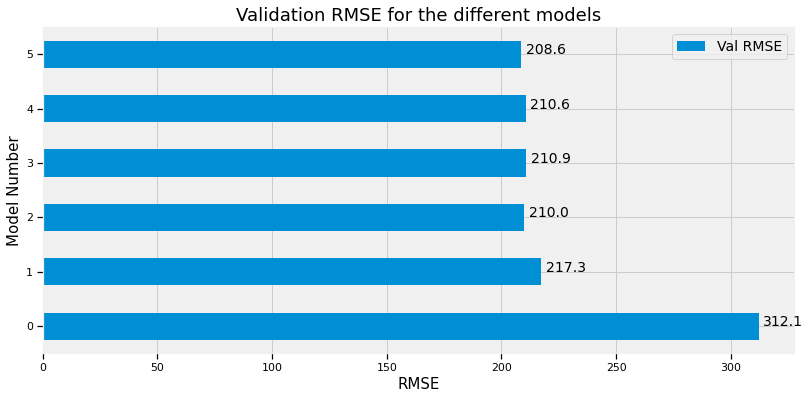

```python
# Print summary of validation RMSE
models = ['0', '1', '2', '3', '4', '5']
model_summary = pd.DataFrame.from_dict({
    'Model': models,
    'Val RMSE': [eval('val_error_' + m) for m in models]
}).set_index('Model')
model_summary.plot(kind='barh', figsize = (12, 6))

plt.xlabel('RMSE', fontsize = 15)
plt.ylabel('Model Number', fontsize = 15)
plt.legend(fontsize = 14)
plt.title('Validation RMSE for the different models', fontsize = 18)
[plt.text(y + 2, int(x), '{:.1f}'.format(y), fontsize = 14) for x, y in model_summary.itertuples()];
```

Based on the plot, model 5 has the lowest RMSE; however, it is clear that all of the models perform very similarly except for the naive model (model 0). It is clear that adding more features lower the RMSE since the model becomes more complex. Basing solely on RMSE, the final model will be model 5.

# 3 Final Model and remarks

```python
def poly_features(df, num_features, degree = 2):
  """Create Polynomial features"""

  # Import polynomial transformation function from scikit-learn
  from sklearn.preprocessing import PolynomialFeatures
  transformer = PolynomialFeatures(degree = degree, include_bias = False)

  # Add only the second order polynomial features to the existing dataframe
  new_features = []
  for feat in num_features:
      poly = transformer.fit_transform(df[[feat]])
      temp = pd.DataFrame(poly[:, 1], columns = [feat + '^2'], index = df.index)
      df = pd.concat([df, temp], axis = 1)
      new_features.append(feat + '^2') # Record the newly added features

  num_features.extend(new_features)

  return num_features, df
```

```python
# Creating pipeline

def process_data(df, num_features, cat_features, degree = 2):
    """Process the data for hourly rides with the features to be used."""

    if num_features is not None:

      # Get new list of numerical features and new dataframe
      num_features, df = poly_features(df, num_features, degree)

      # Fit scaler (basically get the mean and stdev) for the training data
      scaler = StandardScaler()
      scaler.fit(df[num_features])
      scaled = df[num_features].copy()

      # Convert numeric features to standard units
      scaled.iloc[:, :] = scaler.transform(scaled)

    else:

      # If there are no numerical features, create a filler dataframe of zeros with the same index
      scaled = pd.DataFrame(np.zeros((df.shape[0], 1)), columns = ['fill'], index = df.index)

    if cat_features is not None:

      # Convert categorical features using dummy encoding
      categoricals = [pd.get_dummies(df[s], prefix=s, drop_first=True) for s in cat_features]

    else:

      # If there are no categorical features, create a filler dataframe of zeros with the same index
      categoricals = [pd.DataFrame(np.zeros((df.shape[0], 1)), columns = ['fill'], index = df.index)]

    # Return predictors and response variables separately
    X = pd.concat([scaled] + categoricals, axis=1)
    y = df.loc[:, 'rides']

    # Remove the filler column
    if 'fill' in X.columns:
      X.drop(columns = 'fill', inplace = True)

    return X, y
```

```python
# Evaluate the final model against the test set

# Define numerical features to use
num_features = ['temp', 'rel_hum', 'wind_speed']

# Define categorical features to use
cat_features = ['month', 'day', 'hour', 'holiday', 'Weather_simple']

# Model and output test error
X_test, y_test = process_data(test, num_features, cat_features)
final_model = model_5
y_predicted = final_model.predict(X_test)
test_error = rmse(y_test, y_predicted)

# Print answers
print('Test RMSE: {} rides'.format(round(test_error,2)))
```

```
Test RMSE: 208.06 rides
```

In general, the models were not significantly different enough for any meaningful comparison. One of the main issues is the lack of complexity in the model. A method of addressing this issue is by collecting other information such as vehicular traffic in order to increase the number of features used for modelling. Using neural networks could also produce differentiable results given that the algorithm learns its own features. Further investigation in modelling is definitely warranted.